# ipl_match_prediction

## 1. Problem Definition

**Research question:** Can pre-match information (recent form, head-to-head record, venue, and toss) predict the winner of an IPL match?

- **Target variable:** a_wins — 1 if randomly assigned Team A won, 0 if Team B won.
- **Task type:** binary classification.
- **Who could benefit:** team analysts and coaches, broadcasters and journalists, and fans who want to know whether common pre-match beliefs hold up.
- **Why it matters:** fans and commentators often treat form, home ground, and the toss as decisive. Testing these claims with data shows whether pre-match narratives are justified.

## 2. Background and Context

The IPL is a T20 league of 8–10 franchise teams. Before each match, captains toss a coin and the winner chooses to bat or field. T20 matches are short, so a single over can change the result, and squads change between seasons through player auctions.

**The toss:** A study of over 300 T20 internationals found little evidence that winning the toss or batting first improves the chance of winning Sacheti et al., 2016. A larger study of over 35,000 matches found the toss effect is essentially zero in T20s overall, but about 3.3 percentage points in day/night limited-overs matches (Lal et al., 2023).

**Home advantage:** In English one-day county cricket, home teams won 57% of decided matches, though team quality mattered more than the toss Morley & Thomas, 2005.

**Previous IPL prediction:** Srikantaiah et al. 2021 compared SVM, random forest, logistic regression, and KNN using player-level statistics and reported 88% accuracy with a random forest. This project uses only team-level pre-match features and tests on future seasons the model has never seen, giving a more conservative estimate.

**Expectation:** research suggests the toss and home advantage have small effects in T20, so recent form and head-to-head (measures of team strength) were expected to matter most.

## 3. Data Description

- **Source:** IPL Complete Dataset (2008–2024) by Patrick B. on Kaggle, originally from Cricsheet: https://www.kaggle.com/datasets/patrickb1912/ipl-complete-dataset-20082020
- **Each row:** one IPL match.
- **Size:** 1,095 matches, 20 columns, 17 seasons (2008–2024). 1,090 remain after removing no-result matches.
- **Target distribution:** in the raw data, team1 was the home team in 52.6% of matches but team2 in only 11.7%, so column order was not random. After randomly assigning Team A, the target is balanced (Team A won 50.8%), so there is no class imbalance.
- **Available features:** season, date, city, venue, team1, team2, toss winner, toss decision, winner, plus post-match columns (result margin, player of the match, target runs) that I excluded.
- **Limitations:** no player lineups, injuries, pitch, or weather data; franchises renamed over time; some seasons played at neutral venues 2009 South Africa, 2020 UAE. Missing values: city (51), winner and player_of_match 5 each, the no-result matches, result_margin 19, target_runs and target_overs 3 each, and method 1,074, filled only for rain-affected matches.

## 5. Data Preparation and Feature Selection

- **Missing/inconsistent data:** removed no-result matches no winner; merged renamed franchises e.g., Delhi Daredevils → Delhi Capitals; standardized city names Bangalore → Bengaluru; converted date to datetime and created year.
- **Features included:** recent form last 5 matches, head-to-head wins, home city indicator, toss winner, and toss decision. All were engineered using only matches before each game. The final model uses their Team A minus Team B differences.
- **Excluded:** player_of_match, result, result_margin, target_runs, target_overs, super_over, and method leak the result; umpires are irrelevant.
- **Encoding/scaling:** toss and home features coded 0/1; numeric features scaled with StandardScaler for logistic regression.
- **Split:** train on 2008–2022 946 matches, test on 2023–2024 144 matches.
- **Leakage prevention:** time-based split, features built only from earlier matches, scaling fitted inside a pipeline on training data only.

## 6. Baseline and Model Development

- **Baselines:** majority class 48.6% and toss winner wins 45.1%. They show what accuracy is possible without a model.
- **Models:** logistic regression interpretable, gives win probabilities, standard for binary outcomes and random forest captures nonlinear interactions, such as the toss mattering more at some venues.
- **Tuning:** limited random forest depth to 5 to prevent overfitting, and compared two feature sets 9 raw features vs. 5 difference features using 5-fold time-series cross-validation.
- **Fair comparison:** both models used identical training and test sets, the same features, and the same random seed 42.

## 9. Limitations, Ethics, and Reflection

- **Biases and gaps:** newer teams have little history; squads change after auctions, so old head-to-head records describe different players; neutral-venue seasons distort home advantage; no player, injury, or weather data.
- **Who is affected:** bettors and fantasy players could lose money; teams and captains could face unfair media narratives.
- **Error consequences:** since Team A is random, false positives and false negatives are the same mistake, picking the wrong winner. Confident wrong predictions are the most harmful because they create false certainty.
- **Real-world use:** not appropriate for betting or team decisions, since it performs at chance level.
- **Next steps:** player-level features from `deliveries.csv`, squad strength after each auction, and testing other form windows.
- **What users should know:** these pre-match factors do not reliably predict IPL winners.

## 10. Code and Transparency

- **Code:** https://github.com/modias/ipl-match-winner-prediction
- **Data:** Patrick B. (2024), IPL Complete Dataset, Kaggle.
- **Documentation used:** pandas and scikit-learn documentation.
- **AI usage:** I used Claude (Anthropic, Claude Opus 5.5) to help find the dataset, debug my Python code, and reword and edit my written explanations in the notebook markdown and README file. I reviewed, ran, and verified all code and results myself.

### References

Lal, A., Willis, D., Sood, G., & Acharya, A. (2023). Fairly random: The effect of winning the toss on winning the match. *Journal of Sports Analytics*. https://science.ecosyste.ms/projects/30509

Morley, B., & Thomas, D. (2005). An investigation of home advantage and other factors affecting outcomes in English one-day cricket matches. *Journal of Sports Sciences, 23*(3), 261–268. https://pubmed.ncbi.nlm.nih.gov/15966344/

Srikantaiah, K. C., Khetan, A., Kumar, B., Tolani, D., & Patel, H. (2021). Prediction of IPL match outcome using machine learning techniques. In *Proceedings of the 3rd International Conference on Integrated Intelligent Computing Communication & Security*. Atlantis Press. https://doi.org/10.2991/ahis.k.210913.049

Patrick B. (2024). *IPL complete dataset (2008–2024)* [Data set]. Kaggle. https://www.kaggle.com/datasets/patrickb1912/ipl-complete-dataset-20082020

```python
import pandas as pd
import numpy as np
import matplotlib.pyplot as plt
import os
from sklearn.metrics import accuracy_score
from sklearn.linear_model import LogisticRegression
from sklearn.ensemble import RandomForestClassifier
from sklearn.preprocessing import StandardScaler
from sklearn.pipeline import make_pipeline
from sklearn.metrics import accuracy_score, roc_auc_score
from sklearn.model_selection import TimeSeriesSplit, cross_val_score
from sklearn.metrics import ConfusionMatrixDisplay
from sklearn.inspection import permutation_importance
```

```python
df = pd.read_csv('/Users/amodi/Documents/DTSC2301PJ2/Dataset/matches.csv')
df.head
```

```
<bound method NDFrame.head of            id   season        city        date   match_type  player_of_match  \
0      335982  2007/08   Bangalore  2008-04-18       League      BB McCullum
1      335983  2007/08  Chandigarh  2008-04-19       League       MEK Hussey
2      335984  2007/08       Delhi  2008-04-19       League      MF Maharoof
3      335985  2007/08      Mumbai  2008-04-20       League       MV Boucher
4      335986  2007/08     Kolkata  2008-04-20       League        DJ Hussey
...       ...      ...         ...         ...          ...              ...
1090  1426307     2024   Hyderabad  2024-05-19       League  Abhishek Sharma
1091  1426309     2024   Ahmedabad  2024-05-21  Qualifier 1         MA Starc
1092  1426310     2024   Ahmedabad  2024-05-22   Eliminator         R Ashwin
1093  1426311     2024     Chennai  2024-05-24  Qualifier 2    Shahbaz Ahmed
1094  1426312     2024     Chennai  2024-05-26        Final         MA Starc

                                                  venue  \
0                                 M Chinnaswamy Stadium
```

[output cut: 64 more lines]

```python
df.shape
df.info
df.isnull().sum()
```

```
id                    0
season                0
city                 51
date                  0
match_type            0
player_of_match       5
venue                 0
team1                 0
team2                 0
toss_winner           0
toss_decision         0
winner                5
result                0
result_margin        19
target_runs           3
target_overs          3
super_over            0
method             1074
umpire1               0
umpire2               0
dtype: int64
```

```python
df.describe().T
```

|  | count | mean | std | min | 25% | 50% | 75% | max |
| --- | --- | --- | --- | --- | --- | --- | --- | --- |
| id | 1095.0 | 904828.319635 | 367740.242299 | 335982.0 | 548331.5 | 980961.0 | 1254062.5 | 1426312.0 |
| result_margin | 1076.0 | 17.259294 | 21.787444 | 1.0 | 6.0 | 8.0 | 20.0 | 146.0 |
| target_runs | 1092.0 | 165.684066 | 33.427048 | 43.0 | 146.0 | 166.0 | 187.0 | 288.0 |
| target_overs | 1092.0 | 19.759341 | 1.581108 | 5.0 | 20.0 | 20.0 | 20.0 | 20.0 |

```python
#Convert date from text to real dates, and create a clean year column
df['date'] = pd.to_datetime(df['date'])
df['year'] = df['date'].dt.year

# renamed franchises
team_map = {
    'Delhi Daredevils': 'Delhi Capitals',
    'Kings XI Punjab': 'Punjab Kings',
    'Rising Pune Supergiants': 'Rising Pune Supergiant',
    'Royal Challengers Bangalore': 'Royal Challengers Bengaluru',
}
for col in ['team1', 'team2', 'toss_winner', 'winner']:
    df[col] = df[col].replace(team_map)


df = df[df['winner'].notna()].copy()
df = df.sort_values('date').reset_index(drop=True)
print(df.shape)
df[['season', 'year', 'date', 'team1', 'team2', 'winner']].head()
```

```
(1090, 21)
```

|  | season | year | date | team1 | team2 | winner |
| --- | --- | --- | --- | --- | --- | --- |
| 0 | 2007/08 | 2008 | 2008-04-18 | Royal Challengers Bengaluru | Kolkata Knight Riders | Kolkata Knight Riders |
| 1 | 2007/08 | 2008 | 2008-04-19 | Punjab Kings | Chennai Super Kings | Chennai Super Kings |
| 2 | 2007/08 | 2008 | 2008-04-19 | Delhi Capitals | Rajasthan Royals | Delhi Capitals |
| 3 | 2007/08 | 2008 | 2008-04-20 | Mumbai Indians | Royal Challengers Bengaluru | Royal Challengers Bengaluru |
| 4 | 2007/08 | 2008 | 2008-04-20 | Kolkata Knight Riders | Deccan Chargers | Kolkata Knight Riders |

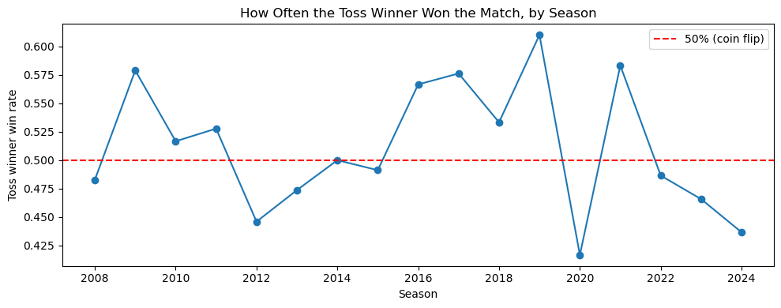

```python
toss_by_year = df.groupby('year').apply(lambda g: (g['toss_winner'] == g['winner']).mean())
toss_by_year.plot(marker='o', figsize=(10, 4))
plt.axhline(0.5, color='red', linestyle='--', label='50% (coin flip)')
plt.title('How Often the Toss Winner Won the Match, by Season')
plt.xlabel('Season')
plt.ylabel('Toss winner win rate')
plt.legend()
plt.tight_layout()
plt.savefig('figures/toss_win_rate.png', dpi=150)
plt.show()
```

```python
h2h_records_team1 = []
h2h_records_team2 = []

for row in df.iterrows():
    current_team = row[1]['team1']
    opponent_team = row[1]['team2']
    date = row[1]['date']
    h2_history = df[((df['team1'] == current_team) & (df['team2'] == opponent_team)) | ((df['team1'] == opponent_team) & (df['team2'] == current_team))].loc[df['date'] < date]
    h2h_records_where_team1_won = h2_history[h2_history['winner'] == current_team]
    h2h_records_where_team2_won = h2_history[h2_history['winner'] == opponent_team]
    h2h_records_team1.append(len(h2h_records_where_team1_won))
    h2h_records_team2.append(len(h2h_records_where_team2_won))

h2h_records_team1
h2h_records_team2

df['team1_h2h_wins'] = h2h_records_team1
df['team2_h2h_wins'] = h2h_records_team2
df['h2h_meetings'] = df['team1_h2h_wins'] + df['team2_h2h_wins']
df["h2h_team1_win_percentage"] = df["team1_h2h_wins"] / df["h2h_meetings"] * 100
df["h2h_team2_win_percentage"] = df["team2_h2h_wins"] / df["h2h_meetings"] * 100

df[['team1', 'team2', 'team1_h2h_wins', 'team2_h2h_wins', 'h2h_meetings', "h2h_team1_win_percentage", "h2h_team2_win_percentage"]]
```

|  | team1 | team2 | team1_h2h_wins | team2_h2h_wins | h2h_meetings | h2h_team1_win_percentage | h2h_team2_win_percentage |
| --- | --- | --- | --- | --- | --- | --- | --- |
| 0 | Royal Challengers Bengaluru | Kolkata Knight Riders | 0 | 0 | 0 | NaN | NaN |
| 1 | Punjab Kings | Chennai Super Kings | 0 | 0 | 0 | NaN | NaN |
| 2 | Delhi Capitals | Rajasthan Royals | 0 | 0 | 0 | NaN | NaN |
| 3 | Mumbai Indians | Royal Challengers Bengaluru | 0 | 0 | 0 | NaN | NaN |
| 4 | Kolkata Knight Riders | Deccan Chargers | 0 | 0 | 0 | NaN | NaN |
| ... | ... | ... | ... | ... | ... | ... | ... |
| 1085 | Punjab Kings | Sunrisers Hyderabad | 7 | 15 | 22 | 31.818182 | 68.181818 |
| 1086 | Sunrisers Hyderabad | Kolkata Knight Riders | 9 | 17 | 26 | 34.615385 | 65.384615 |
| 1087 | Royal Challengers Bengaluru | Rajasthan Royals | 15 | 13 | 28 | 53.571429 | 46.428571 |
| 1088 | Sunrisers Hyderabad | Rajasthan Royals | 10 | 9 | 19 | 52.631579 | 47.368421 |
| 1089 | Sunrisers Hyderabad | Kolkata Knight Riders | 9 | 18 | 27 | 33.333333 | 66.666667 |

1090 rows × 7 columns

```python
team1_form, team2_form = [], []
team1_prev, team2_prev = [], []

for _, row in df.iterrows():
    date = row['date']

    for team, form_list, prev_list in [(row['team1'], team1_form, team1_prev),
                                       (row['team2'], team2_form, team2_prev)]:
        # All this team's matches BEFORE this date
        past = df[((df['team1'] == team) | (df['team2'] == team)) & (df['date'] < date)]
        last5 = past.tail(5)

        prev_list.append(len(past))   # how many games of history

        if len(last5) == 0:
            form_list.append(0.5)     # first-ever game: neutral value
        else:
            form_list.append((last5['winner'] == team).mean())

df['team1_form'] = team1_form
df['team2_form'] = team2_form
df['team1_prev_matches'] = team1_prev
df['team2_prev_matches'] = team2_prev

df[['date', 'team1', 'team2', 'winner', 'team1_form', 'team2_form',
    'team1_prev_matches', 'team2_prev_matches']]
```

|  | date | team1 | team2 | winner | team1_form | team2_form | team1_prev_matches | team2_prev_matches |
| --- | --- | --- | --- | --- | --- | --- | --- | --- |
| 0 | 2008-04-18 | Royal Challengers Bengaluru | Kolkata Knight Riders | Kolkata Knight Riders | 0.5 | 0.5 | 0 | 0 |
| 1 | 2008-04-19 | Punjab Kings | Chennai Super Kings | Chennai Super Kings | 0.5 | 0.5 | 0 | 0 |
| 2 | 2008-04-19 | Delhi Capitals | Rajasthan Royals | Delhi Capitals | 0.5 | 0.5 | 0 | 0 |
| 3 | 2008-04-20 | Mumbai Indians | Royal Challengers Bengaluru | Royal Challengers Bengaluru | 0.5 | 0.0 | 0 | 1 |
| 4 | 2008-04-20 | Kolkata Knight Riders | Deccan Chargers | Kolkata Knight Riders | 1.0 | 0.5 | 1 | 0 |
| ... | ... | ... | ... | ... | ... | ... | ... | ... |
| 1085 | 2024-05-19 | Punjab Kings | Sunrisers Hyderabad | Sunrisers Hyderabad | 0.6 | 0.4 | 245 | 178 |
| 1086 | 2024-05-21 | Sunrisers Hyderabad | Kolkata Knight Riders | Kolkata Knight Riders | 0.6 | 0.8 | 179 | 249 |
| 1087 | 2024-05-22 | Royal Challengers Bengaluru | Rajasthan Royals | Rajasthan Royals | 1.0 | 0.2 | 251 | 217 |
| 1088 | 2024-05-24 | Sunrisers Hyderabad | Rajasthan Royals | Sunrisers Hyderabad | 0.6 | 0.2 | 180 | 218 |
| 1089 | 2024-05-26 | Sunrisers Hyderabad | Kolkata Knight Riders | Kolkata Knight Riders | 0.6 | 1.0 | 181 | 250 |

1090 rows × 8 columns

```python
home_city = {
    'Chennai Super Kings': 'Chennai',
    'Delhi Capitals': 'Delhi',
    'Gujarat Titans': 'Ahmedabad',
    'Kolkata Knight Riders': 'Kolkata',
    'Lucknow Super Giants': 'Lucknow',
    'Mumbai Indians': 'Mumbai',
    'Punjab Kings': 'Mohali',
    'Rajasthan Royals': 'Jaipur',
    'Royal Challengers Bengaluru': 'Bengaluru',
    'Rising Pune Supergiant': 'Pune',
    'Sunrisers Hyderabad': 'Hyderabad',
    'Gujarat Lions': 'Rajkot',
    'Kochi Tuskers Kerala': 'Kochi',
    'Pune Warriors': 'Pune',
    'Deccan Chargers': 'Hyderabad',
}

new_city_name = {
    'Bangalore': 'Bengaluru',
    'New Delhi': 'Delhi',
    'Chandigarh': 'Mohali',
}

df['city'] = df['city'].map(new_city_name).fillna(df['city'])
df['team1_home'] = (df['city'] == df['team1'].map(home_city)).astype(int)
df['team2_home'] = (df['city'] == df['team2'].map(home_city)).astype(int)

df[['date', 'city', 'team1', 'team2', 'team1_home', 'team2_home']]
print(df['team1_home'].mean(), df['team2_home'].mean())
```

```
0.5256880733944954 0.11651376146788991
```

```python
rng = np.random.default_rng(seed=42)
swap = rng.random(len(df)) < 0.5

def a_b(col1, col2):
    return np.where(swap, df[col2], df[col1]), np.where(swap, df[col1], df[col2])

model_df = pd.DataFrame(index=df.index)
model_df['year'] = df['year']
model_df['team_a'], model_df['team_b'] = a_b('team1', 'team2')
model_df['a_form'], model_df['b_form'] = a_b('team1_form', 'team2_form')
model_df['a_prev_matches'], model_df['b_prev_matches'] = a_b('team1_prev_matches', 'team2_prev_matches')
model_df['a_home'], model_df['b_home'] = a_b('team1_home', 'team2_home')
a_h2h, b_h2h = a_b('team1_h2h_wins', 'team2_h2h_wins')
model_df['h2h_diff'] = a_h2h - b_h2h
model_df['a_won_toss'] = (df['toss_winner'] == model_df['team_a']).astype(int)
model_df['toss_bat'] = (df['toss_decision'] == 'bat').astype(int)
model_df['a_wins'] = (df['winner'] == model_df['team_a']).astype(int)
model_df['form_diff'] = model_df['a_form'] - model_df['b_form']
model_df['home_diff'] = model_df['a_home'] - model_df['b_home']

features = ['a_form', 'b_form', 'a_prev_matches', 'b_prev_matches',
            'a_home', 'b_home', 'h2h_diff', 'a_won_toss', 'toss_bat']
train = model_df[model_df['year'] <= 2022]
test = model_df[model_df['year'] >= 2023]
X_train, y_train = train[features], train['a_wins']
X_test, y_test = test[features], test['a_wins']

print(f"Team A win rate: {model_df['a_wins'].mean():.3f}")
print(f"Train: {len(train)} matches, Test: {len(test)} matches")
model_df.head(10)
```

```
Team A win rate: 0.508
Train: 946 matches, Test: 144 matches
```

|  | year | team_a | team_b | a_form | b_form | a_prev_matches | b_prev_matches | a_home | b_home | h2h_diff | a_won_toss | toss_bat | a_wins | form_diff | home_diff |
| --- | --- | --- | --- | --- | --- | --- | --- | --- | --- | --- | --- | --- | --- | --- | --- |
| 0 | 2008 | Royal Challengers Bengaluru | Kolkata Knight Riders | 0.5 | 0.5 | 0 | 0 | 1 | 0 | 0 | 1 | 0 | 0 | 0.0 | 1 |
| 1 | 2008 | Chennai Super Kings | Punjab Kings | 0.5 | 0.5 | 0 | 0 | 0 | 1 | 0 | 1 | 1 | 1 | 0.0 | -1 |
| 2 | 2008 | Delhi Capitals | Rajasthan Royals | 0.5 | 0.5 | 0 | 0 | 1 | 0 | 0 | 0 | 1 | 1 | 0.0 | 1 |
| 3 | 2008 | Mumbai Indians | Royal Challengers Bengaluru | 0.5 | 0.0 | 0 | 1 | 1 | 0 | 0 | 1 | 1 | 0 | 0.5 | 1 |
| 4 | 2008 | Deccan Chargers | Kolkata Knight Riders | 0.5 | 1.0 | 0 | 1 | 0 | 1 | 0 | 1 | 1 | 0 | -0.5 | -1 |
| 5 | 2008 | Rajasthan Royals | Punjab Kings | 0.0 | 0.0 | 1 | 1 | 1 | 0 | 0 | 0 | 1 | 1 | 0.0 | 1 |
| 6 | 2008 | Deccan Chargers | Delhi Capitals | 0.0 | 1.0 | 1 | 1 | 1 | 0 | 0 | 1 | 1 | 0 | -1.0 | 1 |
| 7 | 2008 | Chennai Super Kings | Mumbai Indians | 1.0 | 0.0 | 1 | 1 | 1 | 0 | 0 | 0 | 0 | 1 | 1.0 | 1 |
| 8 | 2008 | Rajasthan Royals | Deccan Chargers | 0.5 | 0.0 | 2 | 2 | 0 | 1 | 0 | 1 | 0 | 1 | 0.5 | -1 |
| 9 | 2008 | Mumbai Indians | Punjab Kings | 0.0 | 0.0 | 2 | 2 | 0 | 1 | 0 | 1 | 0 | 0 | 0.0 | -1 |

```python
toss_baseline = accuracy_score(y_test, X_test['a_won_toss'])
print(f"Toss-winner baseline accuracy: {toss_baseline:.3f}")
```

```
Toss-winner baseline accuracy: 0.451
```

```python
features = ['a_form', 'b_form', 'a_prev_matches', 'b_prev_matches',
            'a_home', 'b_home', 'h2h_diff', 'a_won_toss', 'toss_bat']
train = model_df[model_df['year'] <= 2022]
test = model_df[model_df['year'] >= 2023]
X_train, y_train = train[features], train['a_wins']
X_test, y_test = test[features], test['a_wins']
print(f"Train: {len(train)} matches, Test: {len(test)} matches")
```

```
Train: 946 matches, Test: 144 matches
```

```python
swap = rng.random(len(df)) < 0.5

def a_b(col1, col2):
    return np.where(swap, df[col2], df[col1]), np.where(swap, df[col1], df[col2])

model_df = pd.DataFrame(index=df.index)
model_df['year'] = df['year']
model_df['team_a'], model_df['team_b'] = a_b('team1', 'team2')

model_df['a_form'], model_df['b_form'] = a_b('team1_form', 'team2_form')
model_df['a_prev_matches'], model_df['b_prev_matches'] = a_b('team1_prev_matches', 'team2_prev_matches')
model_df['a_home'], model_df['b_home'] = a_b('team1_home', 'team2_home')
a_h2h, b_h2h = a_b('team1_h2h_wins', 'team2_h2h_wins')
model_df['h2h_diff'] = a_h2h - b_h2h
model_df['a_won_toss'] = (df['toss_winner'] == model_df['team_a']).astype(int)
model_df['toss_bat'] = (df['toss_decision'] == 'bat').astype(int)

model_df['a_wins'] = (df['winner'] == model_df['team_a']).astype(int)

print(model_df['a_wins'].mean())
model_df.head(10)
```

```
0.518348623853211
```

|  | year | team_a | team_b | a_form | b_form | a_prev_matches | b_prev_matches | a_home | b_home | h2h_diff | a_won_toss | toss_bat | a_wins |
| --- | --- | --- | --- | --- | --- | --- | --- | --- | --- | --- | --- | --- | --- |
| 0 | 2008 | Kolkata Knight Riders | Royal Challengers Bengaluru | 0.5 | 0.5 | 0 | 0 | 0 | 1 | 0 | 0 | 0 | 1 |
| 1 | 2008 | Punjab Kings | Chennai Super Kings | 0.5 | 0.5 | 0 | 0 | 1 | 0 | 0 | 0 | 1 | 0 |
| 2 | 2008 | Rajasthan Royals | Delhi Capitals | 0.5 | 0.5 | 0 | 0 | 0 | 1 | 0 | 1 | 1 | 0 |
| 3 | 2008 | Royal Challengers Bengaluru | Mumbai Indians | 0.0 | 0.5 | 1 | 0 | 0 | 1 | 0 | 0 | 1 | 1 |
| 4 | 2008 | Kolkata Knight Riders | Deccan Chargers | 1.0 | 0.5 | 1 | 0 | 1 | 0 | 0 | 0 | 1 | 1 |
| 5 | 2008 | Punjab Kings | Rajasthan Royals | 0.0 | 0.0 | 1 | 1 | 0 | 1 | 0 | 1 | 1 | 0 |
| 6 | 2008 | Delhi Capitals | Deccan Chargers | 1.0 | 0.0 | 1 | 1 | 0 | 1 | 0 | 0 | 1 | 1 |
| 7 | 2008 | Chennai Super Kings | Mumbai Indians | 1.0 | 0.0 | 1 | 1 | 1 | 0 | 0 | 0 | 0 | 1 |
| 8 | 2008 | Deccan Chargers | Rajasthan Royals | 0.0 | 0.5 | 2 | 2 | 1 | 0 | 0 | 0 | 0 | 0 |
| 9 | 2008 | Mumbai Indians | Punjab Kings | 0.0 | 0.0 | 2 | 2 | 0 | 1 | 0 | 1 | 0 | 0 |

```python
toss_baseline = accuracy_score(y_test, X_test['a_won_toss'])
print(f"Toss-winner baseline accuracy: {toss_baseline:.3f}")
```

```
Toss-winner baseline accuracy: 0.451
```

```python
models = {
    'Logistic Regression': make_pipeline(StandardScaler(), LogisticRegression()),
    'Random Forest': RandomForestClassifier(n_estimators=300, max_depth=5, random_state=42),
}

majority = y_train.mode()[0]
majority_acc = accuracy_score(y_test, [majority] * len(y_test))

results = []
for name, model in models.items():
    model.fit(X_train, y_train)
    preds = model.predict(X_test)
    probs = model.predict_proba(X_test)[:, 1]
    results.append({'Model': name,
                    'Accuracy': accuracy_score(y_test, preds),
                    'ROC-AUC': roc_auc_score(y_test, probs)})

results.append({'Model': 'Majority-class baseline', 'Accuracy': majority_acc, 'ROC-AUC': 0.5})
results.append({'Model': 'Toss-winner baseline', 'Accuracy': toss_baseline, 'ROC-AUC': None})

pd.DataFrame(results).round(3)
```

|  | Model | Accuracy | ROC-AUC |
| --- | --- | --- | --- |
| 0 | Logistic Regression | 0.500 | 0.505 |
| 1 | Random Forest | 0.507 | 0.489 |
| 2 | Majority-class baseline | 0.486 | 0.500 |
| 3 | Toss-winner baseline | 0.451 | NaN |

```python
feature_sets = {
    'All 9 features': features,
    'Difference features': ['form_diff', 'home_diff', 'h2h_diff', 'a_won_toss', 'toss_bat'],
}
tscv = TimeSeriesSplit(n_splits=5)

for fs_name, cols in feature_sets.items():
    for m_name, model in models.items():
        scores = cross_val_score(model, train[cols], train['a_wins'], cv=tscv, scoring='roc_auc')
        print(f"{fs_name:22} | {m_name:20} | CV ROC-AUC = {scores.mean():.3f} ± {scores.std():.3f}")
```

```
All 9 features         | Logistic Regression  | CV ROC-AUC = 0.480 ± 0.046
All 9 features         | Random Forest        | CV ROC-AUC = 0.490 ± 0.052
Difference features    | Logistic Regression  | CV ROC-AUC = 0.502 ± 0.039
Difference features    | Random Forest        | CV ROC-AUC = 0.524 ± 0.039
```

```
Test accuracy: 0.465
Test ROC-AUC:  0.471
```

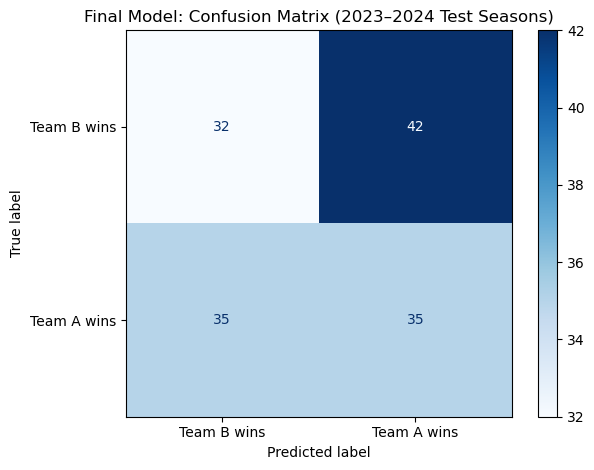

```python
final_features = ['form_diff', 'home_diff', 'h2h_diff', 'a_won_toss', 'toss_bat']

final_model = RandomForestClassifier(n_estimators=300, max_depth=5, random_state=42)
final_model.fit(train[final_features], train['a_wins'])

final_preds = final_model.predict(test[final_features])
final_probs = final_model.predict_proba(test[final_features])[:, 1]
print(f"Test accuracy: {accuracy_score(test['a_wins'], final_preds):.3f}")
print(f"Test ROC-AUC:  {roc_auc_score(test['a_wins'], final_probs):.3f}")

ConfusionMatrixDisplay.from_predictions(
    test['a_wins'], final_preds, display_labels=['Team B wins', 'Team A wins'], cmap='Blues')
plt.title('Final Model: Confusion Matrix (2023–2024 Test Seasons)')
plt.tight_layout()
plt.savefig('figures/confusion_matrix.png', dpi=150)
plt.show()
```

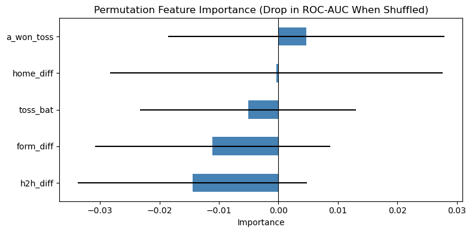

```python
perm = permutation_importance(final_model, test[final_features], test['a_wins'],
                              n_repeats=30, random_state=42, scoring='roc_auc')

imp = pd.Series(perm.importances_mean, index=final_features).sort_values()
err = pd.Series(perm.importances_std, index=final_features)[imp.index]

imp.plot(kind='barh', xerr=err, color='steelblue', figsize=(8, 4))
plt.axvline(0, color='black', linewidth=0.8)
plt.title('Permutation Feature Importance (Drop in ROC-AUC When Shuffled)')
plt.xlabel('Importance')
plt.tight_layout()
plt.savefig('figures/feature_importance.png', dpi=150)
plt.show()
```

```python
model_df['form_diff'] = model_df['a_form'] - model_df['b_form']
model_df.groupby(pd.cut(model_df['form_diff'], [-1.01, -0.3, 0.3, 1.01]), observed=False)['a_wins'].agg(['mean', 'count'])
```

| form_diff | mean | count |
| --- | --- | --- |
| (-1.01, -0.3] | 0.483412 | 211 |
| (-0.3, 0.3] | 0.529240 | 684 |
| (0.3, 1.01] | 0.517949 | 195 |